# Home Data Science Challenge

# Introduction

The goal of this challenge is to come up with the best price for a flat with these characteristics:

- Address: Almstadtstraße 9/11, 10119 Berlin
- Size: 78 sqm
- Floor: 1st
- Rooms: 2
- Built-in kitchen: yes
- Balcony: yes
- Construction year: 1902
- Condition: good
- Quality: good

# Exploratory Analysis and Data Wrangling

```r
library(dplyr)
library(tidyr)
library(ggplot2)
library(FNN)
```

```r
df = read.csv("HomeDataScienceChallenge.csv", sep = ";", dec = ",")
head(df)
```

|  | angebot_id | startdate | enddate | laufzeitw_geschl | ins_vermarktungsbeginn_jahr | oadr_strasse | oadr_plz | oadr_ortsteil | oadr_ort | nachfrageart | objekttyp | objekttyp_fein | kosten | kosten_je_flaeche | kstn_miete_kalt | kstn_nebenkosten | kstn_heizung | kstn_nk_inkl_heizung | kstn_miete_gesamt | flaeche | baujahr | anz_zimmer | etage | etagen | aus_klassen_empirica | aus_barrierefrei_janein | aus_lift_janein | aus_kueche_einbau_janein | aus_heiz_befeuerung | … |
| --- | --- | --- | --- | --- | --- | --- | --- | --- | --- | --- | --- | --- | --- | --- | --- | --- | --- | --- | --- | --- | --- | --- | --- | --- | --- | --- | --- | --- | --- | --- |
| 1 | 3261490501 | 2018-04-23 | 2018-05-09 | 2.4 | 2018 | Max-Beer-Str. 37 | 10119 | Alexanderplatzviertel | Berlin | miete | Wohnung | 4+-Z-Whg | 2715 | 15.78 | 2715 | 350 | NA | 1 | 3065 | 172.00 | 2014 | 5 | 3 | 5 | gut | 1 | 1 | 1 | Gas | … |
| 2 | 3261022455 | 2018-04-21 | 2018-04-27 | 0.8 | 2018 | M\xfcnzstr. 11 | 10178 | Alexanderplatzviertel | Berlin | miete | Wohnung | 2-Z-Whg | 520 | 7.88 | 520 | NA | NA | 0 | NA | 66.00 | 1996 | 2 | 1 | NA | gut | 1 | 0 | 1 | Gas | … |
| 3 | 3259693649 | 2018-04-15 | 2018-04-16 | 0.2 | 2018 | Max-Beer-Str. 25 | 10119 | Alexanderplatzviertel | Berlin | miete | Wohnung | 2-Z-Whg | 602 | 7.00 | 602 | NA | NA | 0 | NA | 86.00 | 1880 | 2 | 1 | NA | normal | 0 | 0 | 0 |  | … |
| 4 | 3259098327 | 2018-04-12 | 2018-04-18 | 0.9 | 2018 | Max-Beer-Str. 19 | 10119 | Alexanderplatzviertel | Berlin | miete | Wohnung | 2-Z-Whg | 890 | 11.90 | 890 | 164 | 89 | 1 | 1054 | 74.77 | 1908 | 2 | 4 | NA | gut | 1 | 0 | 0 | Gas | … |
| 5 | 3259072894 | 2018-04-12 | 2018-04-18 | 0.8 | 2018 | Max-Beer-Str. 19 | 10119 | Alexanderplatzviertel | Berlin | miete | Wohnung | 2-Z-Whg | 890 | 11.90 | 890 | 164 | 89 | 1 | 1054 | 74.77 | 1999 | 2 | 4 | NA | gut | 1 | 0 | 0 | Gas | … |
| 6 | 3249044973 | 2018-02-21 | 2018-02-22 | 0.3 | 2018 | Rosa-Luxemburg-Str. 7 | 10178 | Alexanderplatzviertel | Berlin | miete | Wohnung | 2-Z-Whg | 652 | 13.04 | 652 | 150 | NA | 0 | 802 | 50.00 | 1878 | 2 | 4 | NA | gut | 0 | 1 | 0 |  | … |

The dataset contains information on Kaltmiete, Nebenkosten, Heizungkosten and the overall cost. The overall cost is missing for 3 homes. Given the very small dataset, every data point is precious therefore I will focus on predicting Kaltmiete instead of the overall cost.

The Scikit Learn ML guide agrees with me :P. If your dataset < 50 samples -> Get more data! http://scikit-learn.org/stable/tutorial/machine_learning_map/index.html.

```r
summary(df[c("kosten", "kstn_miete_gesamt")])
```

```
     kosten       kstn_miete_gesamt
 Min.   : 480.0   Min.   : 570
 1st Qu.: 740.5   1st Qu.: 971
 Median : 992.3   Median :1217
 Mean   :1249.9   Mean   :1533
 3rd Qu.:1459.3   3rd Qu.:1772
 Max.   :3500.0   Max.   :4065
                  NA's   :3
```

The flat for which a prediction needs to be made has only a few features available:

- address
- size
- floor
- rooms
- built in kitchen
- balcony
- construction year
- quality
- condition

Therefore, the prediction model should only include these features.

```r
df_mod = df[c(
  "oadr_strasse",
  "flaeche",
  "etage",
  "anz_zimmer",
  "aus_kueche_einbau_janein",
  "aus_balkon_terrasse_janein",
  "baujahr",
  "aus_klassen_empirica",
  "zust_klassen_empirica",
  "kosten"
  )]
```

## Preprocessing and Imputation

It’s important to do some data preprocessing to make the model work. These features are boolean and shouldn’t be considered as numeric ones:

- aus_kueche_einbau_janein
- aus_balkon_terrasse_janein

In R boolean features can be represented with the data type *factor*.

```r
df_mod$aus_kueche_einbau_janein = as.factor(df_mod$aus_kueche_einbau_janein)
df_mod$aus_balkon_terrasse_janein = as.factor(df_mod$aus_balkon_terrasse_janein)
summary(df_mod)
```

```
           oadr_strasse    flaeche           etage         anz_zimmer
 Max-Beer-Str. 6 : 4    Min.   : 41.00   Min.   :0.000   Min.   :1.00
 Max-Beer-Str. 9 : 4    1st Qu.: 56.35   1st Qu.:2.000   1st Qu.:2.00
 Max-Beer-Str. 25: 3    Median : 75.39   Median :3.000   Median :2.00
 Max-Beer-Str. 29: 3    Mean   : 89.18   Mean   :2.804   Mean   :2.77
 Max-Beer-Str. 37: 3    3rd Qu.:116.88   3rd Qu.:4.000   3rd Qu.:3.00
 Almstadtstr. 18 : 2    Max.   :206.00   Max.   :5.000   Max.   :6.00
 (Other)         :31                     NA's   :4
 aus_kueche_einbau_janein aus_balkon_terrasse_janein    baujahr     aus_klassen_empirica
 0:13                     0:18                       Min.   :1831   einfach   : 2
 1:37                     1:32                       1st Qu.:1880   gut       :30
                                                     Median :1906   hochwertig: 8
                                                     Mean   :1929   normal    :10
                                                     3rd Qu.:1998
                                                     Max.   :2014
                                                     NA's   :8
 zust_klassen_empirica     kosten
 gut     :27           Min.   : 480.0
 normal  :21           1st Qu.: 740.5
 schlecht: 2           Median : 992.3
                       Mean   :1249.9
                       3rd Qu.:1459.3
                       Max.   :3500.0
```

There are some missing features in the dataset: the building year is not available for 8 homes. The missing points will be imputed with the median of the building year.

```r
df_mod[is.na(df_mod$baujahr), "baujahr"] <- median(df_mod$baujahr, na.rm = T)
summary(df_mod)
```

```
           oadr_strasse    flaeche           etage         anz_zimmer
 Max-Beer-Str. 6 : 4    Min.   : 41.00   Min.   :0.000   Min.   :1.00
 Max-Beer-Str. 9 : 4    1st Qu.: 56.35   1st Qu.:2.000   1st Qu.:2.00
 Max-Beer-Str. 25: 3    Median : 75.39   Median :3.000   Median :2.00
 Max-Beer-Str. 29: 3    Mean   : 89.18   Mean   :2.804   Mean   :2.77
 Max-Beer-Str. 37: 3    3rd Qu.:116.88   3rd Qu.:4.000   3rd Qu.:3.00
 Almstadtstr. 18 : 2    Max.   :206.00   Max.   :5.000   Max.   :6.00
 (Other)         :31                     NA's   :4
 aus_kueche_einbau_janein aus_balkon_terrasse_janein    baujahr     aus_klassen_empirica
 0:13                     0:18                       Min.   :1831   einfach   : 2
 1:37                     1:32                       1st Qu.:1881   gut       :30
                                                     Median :1906   hochwertig: 8
                                                     Mean   :1925   normal    :10
                                                     3rd Qu.:1992
                                                     Max.   :2014

 zust_klassen_empirica     kosten
 gut     :27           Min.   : 480.0
 normal  :21           1st Qu.: 740.5
 schlecht: 2           Median : 992.3
                       Mean   :1249.9
                       3rd Qu.:1459.3
                       Max.   :3500.0
```

## Feature Analysis

The plot shows that the data supports the relationship between the rent price and:

- number of rooms (1.5 rooms seems to be an outlier in the trend, but only because there’s just 1 flat with 1.5 rooms)
- terrace/balcony (the average price being 114 Euro higher for a flat with a balcony)
- quality
- built in kitchen
- condition

For the floor of a building we observe a weird trend, probably because of the lack of data. It’s hard to believe that the average rent price decreases for buildings on the third floor or higher.

```
attributes are not identical across measure variables;
they will be dropped
```

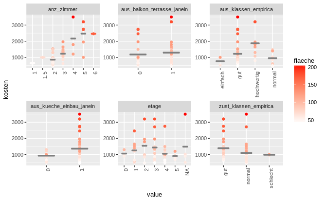

```r
df_mod %>%
  gather(-oadr_strasse, -kosten, -flaeche, -baujahr, key = "var", value = "value") %>%
  ggplot(aes(x = value, y = kosten, col = flaeche)) +
  geom_point() + facet_wrap(~ var, scales = "free") +
  theme(text = element_text(size=10), axis.text.x = element_text(angle=90, hjust=1)) +
  scale_colour_gradient(low = "white",high = "red") +
  stat_summary(fun.y = mean, fun.ymin = mean, fun.ymax = mean, geom = "crossbar", width = 0.5)
```

The plot shows that the relationship between building year and rent price depends on the time period.

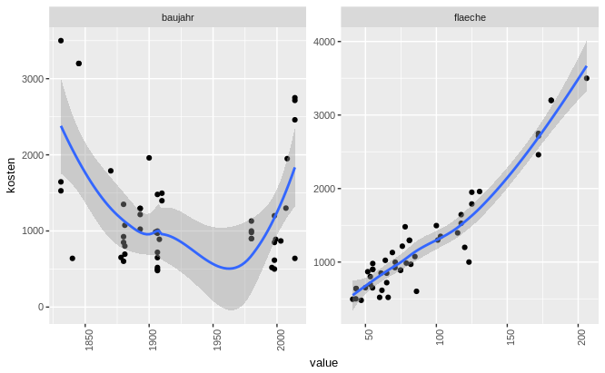

```r
df_mod[, c("kosten", "flaeche", "baujahr")] %>%
  gather(-kosten, key = "var", value = "value") %>%
  ggplot(aes(x = value, y = kosten)) + geom_point() + geom_smooth() +
  facet_wrap( ~ var, scales = "free") +
  theme(text = element_text(size = 10),
  axis.text.x = element_text(angle = 90, hjust = 1))
```

The relation between building year and rent price is best described by a picewise function.

```
Ignoring unknown parameters: method, se
```

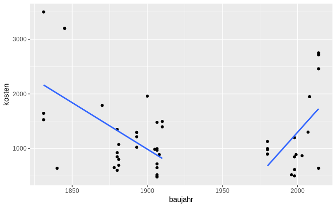

```r
qplot(
  baujahr,
  kosten,
  group = baujahr < 1930,
  geom = c('point', 'smooth'),
  method = 'lm',
  se = F,
  data = df_mod
  )
```

Let’s create a feature that captures this relation.

```r
df_mod$baujahr_below1930 <- ifelse(df_mod$baujahr <= 1930, 0, 1)
df_mod$baujahr_interaction <- df_mod$baujahr_below1930*(df_mod$baujahr-1930)
```

# Model Training

As a first try, I will build a linear regression model.

## Validation Procedure

Splitting data into a training and test set is necessary in order to avoid overfitting (the model memorises instead of learns).

```r
set.seed(100)
train.ix <- sample(1:nrow(df_mod), size = 0.8*nrow(df_mod), replace = F)
df_train <- df_mod[train.ix,]
df_test <- df_mod[-train.ix,]
```

The train test price distribution shouldn’t be too different, but it’s difficult to ensure this with so few data points.

```r
par(mfrow = c(1, 3))
boxplot(df_train$kosten, ylab="Price", main="Training Data")
boxplot(df_test$kosten,  ylab="Price", main="Test Data")
```

[figure not shown]

```r
boxplot(df$kosten,  ylab="Price", main="All Data")
```

## Linear Regression

```r
features <- c('flaeche', 'anz_zimmer', 'baujahr',  'baujahr_interaction',
              'aus_kueche_einbau_janein', 'aus_balkon_terrasse_janein',
              'aus_klassen_empirica', 'zust_klassen_empirica')
features
```

```
[1] "flaeche"                    "anz_zimmer"
[3] "baujahr"                    "baujahr_interaction"
[5] "aus_kueche_einbau_janein"   "aus_balkon_terrasse_janein"
[7] "aus_klassen_empirica"       "zust_klassen_empirica"
```

```r
model_formula <- formula(df_mod[c('kosten', features)])
model_formula
```

```
kosten ~ flaeche + anz_zimmer + baujahr + baujahr_interaction +
    aus_kueche_einbau_janein + aus_balkon_terrasse_janein + aus_klassen_empirica +
    zust_klassen_empirica
```

This model leads to some strange results: e.g. number of rooms seems to have a negative effect on the price which is obviously wrong. The problem is that there’s a high correlation between the number of rooms and flat size (as expected). A model like linear regression may lead to meaningless results in such a situation. To deal with this, I will try a non parametric Machine Learning Model called Kth Nearest Neighbor Regression.

```r
lin_reg = lm(model_formula,
             data = df_train
)
summary(lin_reg)
```

```
Call:
lm(formula = model_formula, data = df_train)

Residuals:
    Min      1Q  Median      3Q     Max
-538.95 -115.75    6.88  168.79  366.24

Coefficients:
                               Estimate Std. Error t value Pr(>|t|)
(Intercept)                    2277.093   4295.818   0.530  0.60024
flaeche                          16.756      2.038   8.222 5.99e-09 ***
anz_zimmer                      -32.403     78.707  -0.412  0.68370
baujahr                          -1.331      2.245  -0.593  0.55798
baujahr_interaction               1.269      3.888   0.326  0.74655
aus_kueche_einbau_janein1        56.811    104.645   0.543  0.59150
aus_balkon_terrasse_janein1      56.243    100.049   0.562  0.57848
aus_klassen_empiricagut         124.761    256.553   0.486  0.63054
aus_klassen_empiricahochwertig  192.846    303.354   0.636  0.53012
aus_klassen_empiricanormal      199.959    253.462   0.789  0.43679
zust_klassen_empiricanormal    -265.874     89.049  -2.986  0.00582 **
zust_klassen_empiricaschlecht  -497.529    210.453  -2.364  0.02525 *
---
Signif. codes:  0 ‘***’ 0.001 ‘**’ 0.01 ‘*’ 0.05 ‘.’ 0.1 ‘ ’ 1

Residual standard error: 228.8 on 28 degrees of freedom
Multiple R-squared:  0.9375,    Adjusted R-squared:  0.9129
F-statistic: 38.18 on 11 and 28 DF,  p-value: 6.433e-14
```

```r
cor(df_mod$flaeche, df_mod$anz_zimmer)
```

```
[1] 0.8403082
```

### Model Validation

The plots show that there are some outliers in the data. Due to the very small amount of data I decided not to remove these outliers.

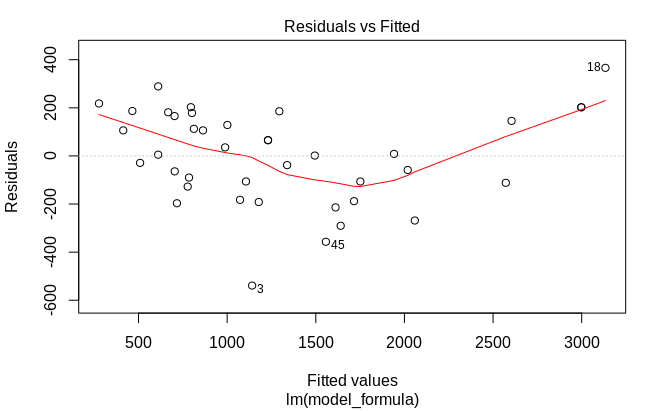

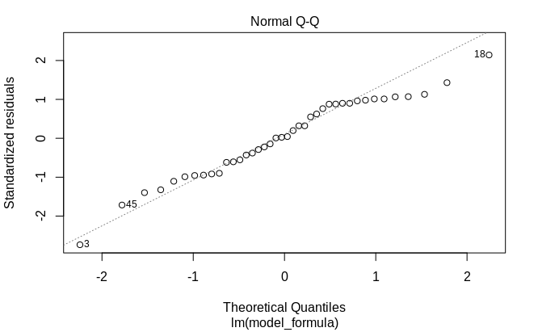

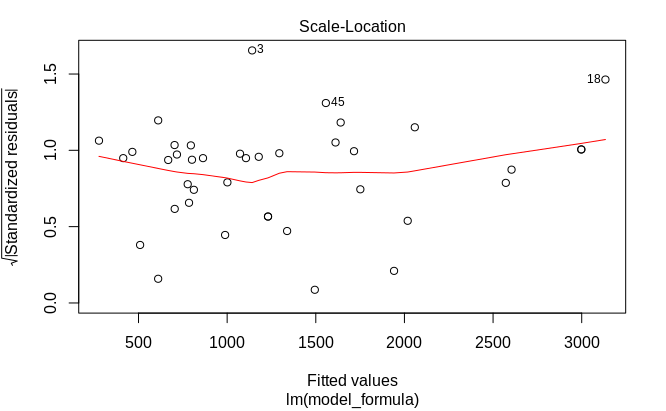

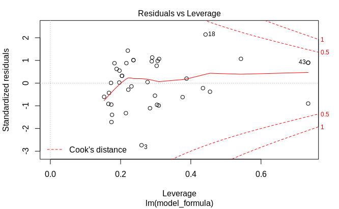

```r
plot(lin_reg)
```

### Error Analysis

For the homes where the predicted rent is higher than the actual one, the average error is 132 Euro. The error is much higher for when we under-predict: on average being 209 Euro. In terms of the percentage of the home price, the error is on average 17.8%. We have to keep in mind that we only have 10 data points for analyzing the error :), so the statistics might not be very reliable.

```r
df_test$predicted_cost = predict(lin_reg, newdata=df_test)
df_test$error = df_test$predicted_cost - df_test$kosten
df_test$perc_error = abs(df_test$predicted_cost - df_test$kosten)/df_test$kosten
mean(df_test$perc_error)
```

```
[1] 0.1787947
```

```r
cor(df_test$kosten, df_test$predicted_cost)
```

```
[1] 0.9410163
```

```r
mean(df_test$error[df_test$error>0])
```

```
[1] 132.1792
```

```r
mean(df_test$error[df_test$error<0])
```

```
[1] -209.9922
```

```r
mean(abs(df_test$error))
```

```
[1] 171.0857
```

### Prediction

The exciting part: what kind of rent will the model predict for our lovely new flat? The prediction from linear regression is 1225 Euro!

```r
df_pred = data.frame(
  flaeche = 78,
  etage = 1,
  avg_room_size = 78/2,
  anz_zimmer = 2,
  aus_kueche_einbau_janein = 1,
  aus_balkon_terrasse_janein = 1,
  baujahr = 1902,
  baujahr_interaction = 0,
  aus_klassen_empirica = 'gut',
  zust_klassen_empirica = 'gut',
  stringsAsFactors = F
  )
df_pred$aus_kueche_einbau_janein <- as.factor(df_pred$aus_kueche_einbau_janein)
df_pred$aus_balkon_terrasse_janein <- as.factor(df_pred$aus_balkon_terrasse_janein)
df_pred
```

| flaeche | etage | avg_room_size | anz_zimmer | aus_kueche_einbau_janein | aus_balkon_terrasse_janein | baujahr | baujahr_interaction | aus_klassen_empirica | zust_klassen_empirica |
| --- | --- | --- | --- | --- | --- | --- | --- | --- | --- |
| 78 | 1 | 39 | 2 | 1 | 1 | 1902 | 0 | gut | gut |

```r
df_pred$predicted_cost = predict(lin_reg, newdata=df_pred)
df_pred$predicted_cost
```

```
[1] 1225.1
```

## Kth Nearest Neighbor Regression

We saw in the previous section that a statistical model like linear regression gave strange results in terms of the effect of the number of rooms on the flat price. To solve the present data issues I try out a Machine Learning model.

```r
x_train <- model.matrix( ~ .-1, df_train[features])
x_train <- subset(x_train, select = -aus_kueche_einbau_janein0)
x_test <- model.matrix( ~ .-1, df_test[features])
x_test <- subset(x_test, select = -aus_kueche_einbau_janein0)
x_full <- model.matrix( ~ .-1, df_mod[features])
x_full <- subset(x_full, select = -aus_kueche_einbau_janein0)
knn <- knn.reg(train = x_train, test = x_test, y = df_train$kosten, k = 3)
df_test$knn_predicted_cost <- knn$pred
df_test$knn_error = df_test$knn_predicted_cost - df_test$kosten
df_test$knn_perc_error = abs(df_test$knn_predicted_cost - df_test$kosten)/df_test$kosten
mean(df_test$knn_perc_error)
```

```
[1] 0.1450623
```

```r
mean(df_test$knn_error[df_test$knn_error>0])
```

```
[1] 157.372
```

```r
mean(df_test$knn_error[df_test$knn_error<0])
```

```
[1] -90.73333
```

```r
mean(abs(df_test$knn_error))
```

```
[1] 124.0527
```

## Prediction

KNN Regression predicts a price of **1145 Euro** for our lovely new flat.

```r
x_pred = data.frame(
  flaeche = 78,
  anz_zimmer = 2,
  aus_kueche_einbau_janein1 = 1,
  aus_balkon_terrasse_janein1 = 1,
  baujahr = 1902,
  baujahr_interaction = 0,
  aus_klassen_empiricagut = 1,
  aus_klassen_empiricahochwertig = 0,
  aus_klassen_empiricanormal = 0,
  zust_klassen_empiricanormal = 0,
  zust_klassen_empiricaschlecht = 0
  )
x_pred = as.matrix(x_pred[colnames(x_train)])
knn.reg(train = x_full, test = x_pred, y = df_mod$kosten, k = 3)
```

```
Prediction:
[1] 1145.527
```